# Assignment 2 — Minimax & Alpha-Beta Pruning

DA 221 · Introduction to Artificial Intelligence · IIT Guwahati

Author

Teaching Material · Prof. Shyamanta M. Hazarika

Published

June 2, 2026

**NoteAssignment 2 Overview**

**Topic:** Minimax Algorithm with Alpha-Beta Pruning on Tic-Tac-Toe  
**Max Marks:** 25 · **Due:** Feb 15, 2024  
**Lectures covered:** M03L08 (Game Playing) and M03L09 (Minimax & Alpha-Beta)

**What you will build:** An agent that plays 3×3 Tic-Tac-Toe using Minimax (Q1) and then optimises it with Alpha-Beta Pruning (Q2).

# 1 Background — From Lectures M03L08 & M03L09

## 1.1 What Assignment 1 Covered (Context)

Assignment 1 used **heuristic / informed search** — specifically the **A* algorithm** — on the 8-puzzle.

| Assignment 1 Concepts | Assignment 2 Concepts |
| --- | --- |
| Single agent searching for a goal | **Two agents** competing against each other |
| A*, Best-First Search | **Minimax** algorithm |
| Heuristics: misplaced tiles, Manhattan distance | **Static evaluation function** (open lines) |
| Admissible heuristic → optimal path | **Alpha-Beta Pruning** → same result, less work |

In Assignment 1 there was only **one player** (us) and one goal (solve the puzzle). Now we face an **adversary** — the opponent actively tries to make us lose.

## 1.2 Key Concepts from the Lectures

**Board games** like Tic-Tac-Toe, Chess, and Checkers share these properties (M03L08):

- **Two players** — called **Max** (us) and **Min** (opponent)
- **Zero-sum** — one player’s gain is the other’s loss
- **Complete information** — both players see the whole board
- **Alternate moves** — players take turns
- **Deterministic** — no randomness

A **game tree** is a layered tree where Max and Min alternate at each level. Max tries to **maximise** the score; Min tries to **minimise** it.

```
            [Max's turn — root]
           /         |         \
       [Min]       [Min]       [Min]      ← Min picks the worst for Max
       /   \       /   \       /   \
    [Max] [Max] [Max] [Max] [Max] [Max]  ← leaf nodes get a score
```

# 2 Block 1 — Setting Up the Board

We represent the board as a 3×3 list. Empty cells are `" "`, player X is `"X"`, player O is `"O"`.

```python
# ── Helper: display the board ──────────────────────────────────────────────

def print_board(board):
    """Print the 3x3 board in a readable format."""
    print()
    for i, row in enumerate(board):
        # Join each cell with a separator
        print("  " + " | ".join(row))
        if i < 2:
            print("  " + "-" * 9)   # row divider (not after last row)
    print()


# ── Try it out ─────────────────────────────────────────────────────────────

# A sample mid-game board: X has center, O has top-right and bottom-right
sample_board = [
    ["X", "O", "X"],
    ["O", "X", " "],
    [" ", " ", "O"]
]

print("Sample board:")
print_board(sample_board)
```

```
Sample board:

  X | O | X
  ---------
  O | X |
  ---------
    |   | O
```

# 3 Block 2 — Checking Game Over

We need two helper functions:

1. **`check_winner`** — did a particular player win?
2. **`is_full`** — is every cell occupied (draw)?

```python
# ── Win detection ──────────────────────────────────────────────────────────

def check_winner(board, player):
    """
    Return True if `player` has three in a row anywhere on the board.
    Checks all 3 rows, all 3 columns, and both diagonals.
    """
    # Check all three rows
    for row in board:
        if all(cell == player for cell in row):
            return True

    # Check all three columns
    for col in range(3):
        if all(board[row][col] == player for row in range(3)):
            return True

    # Check main diagonal (top-left → bottom-right)
    if all(board[i][i] == player for i in range(3)):
        return True

    # Check anti-diagonal (top-right → bottom-left)
    if all(board[i][2 - i] == player for i in range(3)):
        return True

    return False   # no winner found


# ── Draw detection ─────────────────────────────────────────────────────────

def is_full(board):
    """Return True if there are no empty cells left (possible draw)."""
    return all(cell != " " for row in board for cell in row)


# ── Quick tests ────────────────────────────────────────────────────────────

won_board = [
    ["X", "X", "X"],
    ["O", "O", " "],
    [" ", " ", " "]
]
draw_board = [
    ["X", "O", "X"],
    ["X", "X", "O"],
    ["O", "X", "O"]
]

print("X wins horizontal?    ", check_winner(won_board, "X"))   # True
print("O wins in won_board?  ", check_winner(won_board, "O"))   # False
print("draw_board is full?   ", is_full(draw_board))             # True
print("X wins in draw_board? ", check_winner(draw_board, "X"))  # False
```

```
X wins horizontal?     True
O wins in won_board?   False
draw_board is full?    True
X wins in draw_board?  False
```

# 4 Block 3 — The Static Evaluation Function

**ImportantConcept from Lecture M03L08 (Refer Slide Time 33:59)**

The **evaluation function** estimates how good a board state is for Max *without* searching all the way to the end. For Tic-Tac-Toe:

$$e(board) = \text{(lines open for X)} - \text{(lines open for O)}$$

A *line* is open for a player if the opponent has **no piece** on that line yet. Special values:

- **+∞** if X has already won
- **−∞** if O has already won

There are **8 lines** total: 3 rows + 3 columns + 2 diagonals.

```python
# ── Static evaluation function ─────────────────────────────────────────────

def static_eval(board):
    """
    Score the board from X's (Max's) perspective.

    Returns:
        +inf  → X has won
        -inf  → O has won
        score → (lines open for X) minus (lines open for O)
    """
    # First check for terminal wins
    if check_winner(board, "X"):
        return float("inf")
    if check_winner(board, "O"):
        return float("-inf")

    # List all 8 possible winning lines
    lines = [
        # --- rows ---
        [board[0][0], board[0][1], board[0][2]],
        [board[1][0], board[1][1], board[1][2]],
        [board[2][0], board[2][1], board[2][2]],
        # --- columns ---
        [board[0][0], board[1][0], board[2][0]],
        [board[0][1], board[1][1], board[2][1]],
        [board[0][2], board[1][2], board[2][2]],
        # --- diagonals ---
        [board[0][0], board[1][1], board[2][2]],
        [board[0][2], board[1][1], board[2][0]],
    ]

    # A line is "open for X" if O has no piece in it (X can still win via it)
    x_open = sum(1 for line in lines if "O" not in line)
    # A line is "open for O" if X has no piece in it
    o_open = sum(1 for line in lines if "X" not in line)

    return x_open - o_open


# ── Let's see some examples ─────────────────────────────────────────────────

empty_board = [[" ", " ", " "],
               [" ", " ", " "],
               [" ", " ", " "]]

x_center    = [[" ", " ", " "],
               [" ", "X", " "],
               [" ", " ", " "]]

x_winning   = [["X", "X", "X"],
               ["O", "O", " "],
               [" ", " ", " "]]

print("Score for empty board:    ", static_eval(empty_board))  # 0 — perfectly equal
print("Score with X in center:   ", static_eval(x_center))    # positive — X is better
print("Score when X has won:     ", static_eval(x_winning))   # +inf
```

```
Score for empty board:     0
Score with X in center:    4
Score when X has won:      inf
```

# 5 Block 4 — The Minimax Algorithm (Q1)

**NoteConcept from Lecture M03L09 (Minimax Procedure)**

Minimax searches the game tree **depth-first**. At each node:

- **Max’s turn** → pick the child with the **highest** score
- **Min’s turn** → pick the child with the **lowest** score

The backed-up value at the root is the best guaranteed score for Max, assuming Min plays perfectly.

```python
# ── Global counter to track nodes explored ────────────────────────────────
nodes_explored = 0


# ── Minimax (recursive) ───────────────────────────────────────────────────

def minimax(board, depth, is_maximizing):
    """
    Minimax algorithm — returns the best score from this board state.

    Parameters
    ----------
    board          : current 3x3 game board
    depth          : how many more levels to search (0 = stop here)
    is_maximizing  : True if it is X's (Max's) turn, False for O (Min)

    Returns
    -------
    int or float : the minimax value of this board state
    """
    global nodes_explored
    nodes_explored += 1          # count every node we visit

    score = static_eval(board)

    # ── Base cases (stop recursing) ───────────────────────────────────────
    if score == float("inf") or score == float("-inf"):
        return score             # someone has won — game over
    if is_full(board):
        return score             # board is full — draw
    if depth == 0:
        return score             # we've reached our search depth limit

    # ── Recursive case ────────────────────────────────────────────────────
    if is_maximizing:
        # X's turn: try every empty cell, pick the best (highest) outcome
        best = float("-inf")
        for r in range(3):
            for c in range(3):
                if board[r][c] == " ":
                    board[r][c] = "X"                           # make move
                    val = minimax(board, depth - 1, False)      # recurse (Min next)
                    board[r][c] = " "                           # undo move
                    best = max(best, val)
        return best

    else:
        # O's turn: try every empty cell, pick the best (lowest) outcome
        best = float("inf")
        for r in range(3):
            for c in range(3):
                if board[r][c] == " ":
                    board[r][c] = "O"                           # make move
                    val = minimax(board, depth - 1, True)       # recurse (Max next)
                    board[r][c] = " "                           # undo move
                    best = min(best, val)
        return best


# ── Find the best move for X ──────────────────────────────────────────────

def best_move_minimax(board, depth=9):
    """
    Try every legal move for X, run minimax on each, return the best one.
    Returns (row, col) of the best move and the total nodes explored.
    """
    global nodes_explored
    nodes_explored = 0           # reset counter

    best_val = float("-inf")
    move = None

    for r in range(3):
        for c in range(3):
            if board[r][c] == " ":
                board[r][c] = "X"
                val = minimax(board, depth - 1, False)
                board[r][c] = " "
                if val > best_val:
                    best_val = val
                    move = (r, c)

    return move, nodes_explored


# ── Demo: empty board ─────────────────────────────────────────────────────

empty = [[" ", " ", " "], [" ", " ", " "], [" ", " ", " "]]

move, n = best_move_minimax(empty, depth=9)
print(f"Best first move for X (Minimax):  row={move[0]}, col={move[1]}")
print(f"Total nodes explored:             {n:,}")
```

```
Best first move for X (Minimax):  row=0, col=0
Total nodes explored:             549,945
```

## 5.1 Watching Minimax Think — Step by Step

Let’s trace minimax on a **nearly finished** board so the tree is small enough to follow:

```python
# ── A board one move away from X winning ──────────────────────────────────

near_end = [
    ["X", "O", "X"],
    ["O", "X", " "],   # X can win by playing (2, 2)
    [" ", " ", " "]
]

print("Current board (X to move):")
print_board(near_end)

# Manually score every empty cell so we can see minimax reasoning
print("Minimax score for each empty cell (X's perspective):")
print("─" * 40)

for r in range(3):
    for c in range(3):
        if near_end[r][c] == " ":
            near_end[r][c] = "X"
            score = minimax(near_end, depth=8, is_maximizing=False)
            near_end[r][c] = " "

            label = "+inf (WIN!)" if score == float("inf") else str(score)
            print(f"  Move ({r},{c})  →  score = {label}")
```

```
Current board (X to move):

  X | O | X
  ---------
  O | X |
  ---------
    |   |

Minimax score for each empty cell (X's perspective):
────────────────────────────────────────
  Move (1,2)  →  score = +inf (WIN!)
  Move (2,0)  →  score = +inf (WIN!)
  Move (2,1)  →  score = +inf (WIN!)
  Move (2,2)  →  score = +inf (WIN!)
```

# 6 Block 5 — Alpha-Beta Pruning (Q2)

**ImportantConcept from Lecture M03L09 (Alpha-Beta)**

Alpha-Beta is **not a different algorithm** — it is an optimisation layered on top of Minimax. It avoids exploring branches that **cannot affect the final decision**.

- **α (alpha)** = best score Max can guarantee so far
- **β (beta)** = best score Min can guarantee so far

> “The cutout sections of the search space cannot affect the value of the root node.” — M03L09

```python
# ── Minimax WITH Alpha-Beta Pruning ───────────────────────────────────────

nodes_ab = 0   # separate counter for alpha-beta


def minimax_ab(board, depth, alpha, beta, is_maximizing):
    """
    Minimax with Alpha-Beta Pruning.

    Parameters
    ----------
    board         : current 3x3 game board
    depth         : remaining search depth
    alpha         : best score Max can guarantee so far  (starts at -inf)
    beta          : best score Min can guarantee so far  (starts at +inf)
    is_maximizing : True = X's turn, False = O's turn

    Returns
    -------
    int or float : minimax value (same as plain minimax, but faster)
    """
    global nodes_ab
    nodes_ab += 1

    score = static_eval(board)

    # Base cases — exactly the same as plain minimax
    if score == float("inf") or score == float("-inf"):
        return score
    if is_full(board) or depth == 0:
        return score

    if is_maximizing:
        best = float("-inf")
        for r in range(3):
            for c in range(3):
                if board[r][c] == " ":
                    board[r][c] = "X"
                    val = minimax_ab(board, depth - 1, alpha, beta, False)
                    board[r][c] = " "
                    best = max(best, val)
                    alpha = max(alpha, best)   # update best guarantee for Max
                    if beta <= alpha:
                        break                  # ── Beta cutoff! Min won't allow this
        return best

    else:
        best = float("inf")
        for r in range(3):
            for c in range(3):
                if board[r][c] == " ":
                    board[r][c] = "O"
                    val = minimax_ab(board, depth - 1, alpha, beta, True)
                    board[r][c] = " "
                    best = min(best, val)
                    beta = min(beta, best)     # update best guarantee for Min
                    if beta <= alpha:
                        break                  # ── Alpha cutoff! Max won't allow this
        return best


def best_move_ab(board, depth=9):
    """Find the best move for X using Alpha-Beta Pruning."""
    global nodes_ab
    nodes_ab = 0

    best_val = float("-inf")
    move = None

    for r in range(3):
        for c in range(3):
            if board[r][c] == " ":
                board[r][c] = "X"
                val = minimax_ab(board, depth - 1, float("-inf"), float("inf"), False)
                board[r][c] = " "
                if val > best_val:
                    best_val = val
                    move = (r, c)

    return move, nodes_ab


# ── Demo: empty board again, this time with Alpha-Beta ────────────────────

empty = [[" ", " ", " "], [" ", " ", " "], [" ", " ", " "]]

move_ab, n_ab = best_move_ab(empty, depth=9)

# Also run plain minimax for comparison
_, n_mm = best_move_minimax(empty, depth=9)

print(f"Best first move (Alpha-Beta): row={move_ab[0]}, col={move_ab[1]}")
print()
print(f"Nodes explored — Minimax:     {n_mm:>10,}")
print(f"Nodes explored — Alpha-Beta:  {n_ab:>10,}")
print(f"Nodes saved by pruning:       {n_mm - n_ab:>10,}  ({100*(n_mm-n_ab)/n_mm:.1f}% reduction)")
```

```
Best first move (Alpha-Beta): row=0, col=0

Nodes explored — Minimax:        549,945
Nodes explored — Alpha-Beta:      73,007
Nodes saved by pruning:          476,938  (86.7% reduction)
```

# 7 Block 6 — Comparing Minimax vs Alpha-Beta

Now let’s run both algorithms on several board states at different **search depths** and compare how many nodes each explores:

```python
import time

# ── Test boards ───────────────────────────────────────────────────────────

test_cases = {
    "Empty board":   [[" ", " ", " "], [" ", " ", " "], [" ", " ", " "]],
    "X in center":   [[" ", " ", " "], [" ", "X", " "], [" ", " ", " "]],
    "3 moves in":    [["X", " ", "O"], [" ", "X", " "], [" ", " ", "O"]],
}

depths = [3, 6, 9]

# ── Run experiments ────────────────────────────────────────────────────────

print(f"{'Board State':<16} {'Depth':>6} {'Minimax':>12} {'Alpha-Beta':>12} {'Savings':>10}")
print("─" * 62)

results = []   # store for plotting later

for name, state in test_cases.items():
    for d in depths:
        board_copy = [row[:] for row in state]

        # --- Minimax ---
        global nodes_explored
        nodes_explored = 0
        minimax(board_copy, d, True)
        n_mm = nodes_explored

        # --- Alpha-Beta ---
        global nodes_ab
        nodes_ab = 0
        minimax_ab(board_copy, d, float("-inf"), float("inf"), True)
        n_ab_val = nodes_ab

        pct = 100 * (n_mm - n_ab_val) / n_mm if n_mm > 0 else 0
        print(f"{name:<16} {d:>6} {n_mm:>12,} {n_ab_val:>12,} {pct:>9.1f}%")
        results.append((name, d, n_mm, n_ab_val))

    print()   # blank line between board states
```

```
Board State       Depth      Minimax   Alpha-Beta    Savings
──────────────────────────────────────────────────────────────
Empty board           3          586          241      58.9%
Empty board           6       73,450        7,743      89.5%
Empty board           9      549,946       43,628      92.1%

X in center           3          401          240      40.1%
X in center           6       17,681          883      95.0%
X in center           9       40,721        1,584      96.1%

3 moves in            3           74           59      20.3%
3 moves in            6          186          135      27.4%
3 moves in            9          186          135      27.4%
```

## 7.1 Visualising the Savings

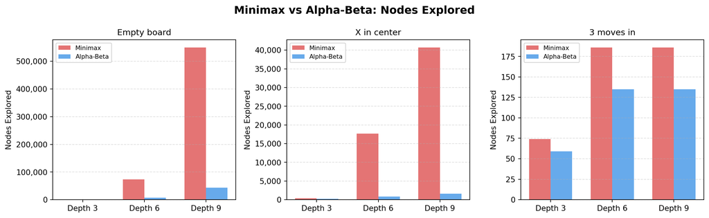

```
Plot saved.
```

```python
import matplotlib.pyplot as plt
import matplotlib.ticker as mticker

# ── Build a bar chart comparing nodes explored ─────────────────────────────

fig, axes = plt.subplots(1, 3, figsize=(13, 4), sharey=False)
fig.suptitle("Minimax vs Alpha-Beta: Nodes Explored", fontsize=14, fontweight="bold")

colors = {"Minimax": "#e05c5c", "Alpha-Beta": "#4c9be8"}

for ax, (name, state) in zip(axes, test_cases.items()):
    mm_vals = [r[2] for r in results if r[0] == name]
    ab_vals = [r[3] for r in results if r[0] == name]

    x = range(len(depths))
    width = 0.35

    bars_mm = ax.bar([i - width/2 for i in x], mm_vals, width,
                     label="Minimax", color=colors["Minimax"], alpha=0.85)
    bars_ab = ax.bar([i + width/2 for i in x], ab_vals, width,
                     label="Alpha-Beta", color=colors["Alpha-Beta"], alpha=0.85)

    ax.set_title(name, fontsize=11)
    ax.set_xticks(list(x))
    ax.set_xticklabels([f"Depth {d}" for d in depths])
    ax.set_ylabel("Nodes Explored")
    ax.yaxis.set_major_formatter(mticker.FuncFormatter(lambda v, _: f"{int(v):,}"))
    ax.legend(fontsize=8)
    ax.grid(axis="y", linestyle="--", alpha=0.4)

plt.tight_layout()
plt.savefig("comparison_plot.png", dpi=120, bbox_inches="tight")
plt.show()
print("Plot saved.")
```

# 8 Block 7 — Interactive Human vs Agent Game

```python
# ── Full Tic-Tac-Toe game: Human (O) vs Agent (X with Alpha-Beta) ─────────

def play_game_demo(human_moves):
    """
    Simulate a game where Human plays O at pre-specified positions.
    The agent (X) uses Alpha-Beta pruning to pick its moves.

    human_moves : list of (row, col) tuples — human's planned moves
    """
    board = [[" ", " ", " "], [" ", " ", " "], [" ", " ", " "]]
    move_queue = list(human_moves)
    turn = 0   # 0 = agent (X), 1 = human (O)

    print("=" * 35)
    print("  GAME START — Agent=X, Human=O")
    print("=" * 35)

    while True:
        print_board(board)

        # ── Check game-over before a new move ──────────────────────────
        if check_winner(board, "X"):
            print(">>> Agent (X) WINS! ✓")
            break
        if check_winner(board, "O"):
            print(">>> Human (O) WINS!")
            break
        if is_full(board):
            print(">>> It's a DRAW!")
            break

        if turn == 0:
            # Agent's turn
            move, n = best_move_ab(board, depth=9)
            if move:
                board[move[0]][move[1]] = "X"
                print(f"  Agent plays at ({move[0]}, {move[1]})  "
                      f"[explored {n:,} nodes]")
        else:
            # Human's turn (pre-scripted for demo)
            if move_queue:
                r, c = move_queue.pop(0)
                if board[r][c] == " ":
                    board[r][c] = "O"
                    print(f"  Human plays at ({r}, {c})")
                else:
                    print(f"  ({r},{c}) already taken — human skips")

        turn = 1 - turn   # swap turns

    print("=" * 35)


# ── Run a sample game ──────────────────────────────────────────────────────
# Human tries to play corners; agent should block and win (or draw)

play_game_demo(human_moves=[(0, 2), (2, 0), (0, 0)])
```

```
===================================
  GAME START — Agent=X, Human=O
===================================

    |   |
  ---------
    |   |
  ---------
    |   |

  Agent plays at (0, 0)  [explored 73,007 nodes]

  X |   |
  ---------
    |   |
  ---------
    |   |

  Human plays at (0, 2)

  X |   | O
  ---------
    |   |
  ---------
    |   |

  Agent plays at (1, 0)  [explored 2,776 nodes]

  X |   | O
  ---------
  X |   |
  ---------
    |   |

  Human plays at (2, 0)

  X |   | O
  ---------
  X |   |
  ---------
```

[output cut: 28 more lines]

```
  ---------
  X | X |
  ---------
  O |   |

  Agent plays at (1, 2)  [explored 3 nodes]

  X | X | O
  ---------
  X | X | X
  ---------
  O |   |

>>> Agent (X) WINS! ✓
===================================
```

# 9 Block 8 — Effectiveness of Alpha-Beta (Report Section)

**TipThis is the basis for your one-page Assignment 2 report**

The assignment asks you to analyse the *gain* from pruning. Here is a structured approach.

```python
# ── Compute savings across a range of depths — the core of your report ────

print("ALPHA-BETA PRUNING — EFFECTIVENESS ANALYSIS")
print("=" * 55)

board_empty = [[" ", " ", " "], [" ", " ", " "], [" ", " ", " "]]

print(f"\n{'Depth':>6} {'Minimax':>12} {'Alpha-Beta':>12} {'Saved %':>10} {'Depth Factor':>14}")
print("─" * 58)

mm_prev = None
for d in range(1, 10):
    b = [row[:] for row in board_empty]
    nodes_explored = 0
    minimax(b, d, True)
    n_mm = nodes_explored

    nodes_ab = 0
    minimax_ab(b, d, float("-inf"), float("inf"), True)
    n_ab_val = nodes_ab

    pct = 100 * (n_mm - n_ab_val) / n_mm if n_mm > 0 else 0

    # Effective branching factor reduction
    factor = (n_mm / n_ab_val) if n_ab_val > 0 else float("inf")

    print(f"{d:>6} {n_mm:>12,} {n_ab_val:>12,} {pct:>9.1f}%  {factor:>13.1f}×")
```

```
ALPHA-BETA PRUNING — EFFECTIVENESS ANALYSIS
=======================================================

 Depth      Minimax   Alpha-Beta    Saved %   Depth Factor
──────────────────────────────────────────────────────────
     1           10           10       0.0%            1.0×
     2           82           49      40.2%            1.7×
     3          586          241      58.9%            2.4×
     4        3,610          924      74.4%            3.9×
     5       18,730        2,966      84.2%            6.3×
     6       73,450        7,743      89.5%            9.5×
     7      221,626       25,367      88.6%            8.7×
     8      422,074       33,697      92.0%           12.5×
     9      549,946       43,628      92.1%           12.6×
```

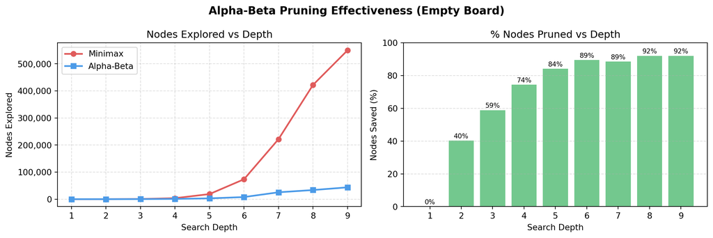

```python
# ── Savings vs depth — line chart ────────────────────────────────────────

depths_range = list(range(1, 10))
mm_nodes, ab_nodes, savings = [], [], []

board_empty = [[" ", " ", " "], [" ", " ", " "], [" ", " ", " "]]

for d in depths_range:
    b = [row[:] for row in board_empty]

    nodes_explored = 0
    minimax(b, d, True)
    n_mm = nodes_explored
    mm_nodes.append(n_mm)

    nodes_ab = 0
    minimax_ab(b, d, float("-inf"), float("inf"), True)
    n_ab_val = nodes_ab
    ab_nodes.append(n_ab_val)

    savings.append(100 * (n_mm - n_ab_val) / n_mm if n_mm > 0 else 0)

fig, (ax1, ax2) = plt.subplots(1, 2, figsize=(12, 4))
fig.suptitle("Alpha-Beta Pruning Effectiveness (Empty Board)", fontsize=13, fontweight="bold")

# Left: node counts
ax1.plot(depths_range, mm_nodes, "o-", color="#e05c5c", linewidth=2, label="Minimax")
ax1.plot(depths_range, ab_nodes, "s-", color="#4c9be8", linewidth=2, label="Alpha-Beta")
ax1.set_xlabel("Search Depth")
ax1.set_ylabel("Nodes Explored")
ax1.set_title("Nodes Explored vs Depth")
ax1.yaxis.set_major_formatter(mticker.FuncFormatter(lambda v, _: f"{int(v):,}"))
ax1.legend()
ax1.grid(linestyle="--", alpha=0.4)
ax1.set_xticks(depths_range)

# Right: percentage saved
ax2.bar(depths_range, savings, color="#5bbf7a", alpha=0.85)
ax2.set_xlabel("Search Depth")
ax2.set_ylabel("Nodes Saved (%)")
ax2.set_title("% Nodes Pruned vs Depth")
ax2.set_ylim(0, 100)
ax2.grid(axis="y", linestyle="--", alpha=0.4)
ax2.set_xticks(depths_range)

for i, (d, s) in enumerate(zip(depths_range, savings)):
    ax2.text(d, s + 1.5, f"{s:.0f}%", ha="center", fontsize=8)

plt.tight_layout()
plt.savefig("effectiveness_plot.png", dpi=120, bbox_inches="tight")
plt.show()
```

# 10 Summary — What to Submit

**NoteAssignment 2 Checklist**

**Q1 — Minimax (15 marks)**

- Implement `minimax(board, depth, is_maximizing)` using the code in Block 4
- Implement `best_move_minimax(board, depth)` to pick X’s move
- Display board after **every** move
- Print “X wins / O wins / Draw” at game end
- Record nodes explored for the report

**Q2 — Alpha-Beta (10 marks)**

- Implement `minimax_ab(board, depth, alpha, beta, is_maximizing)` using Block 5
- Run *both* algorithms on the **same** starting positions
- Record nodes explored for each algorithm
- Verify both produce the **same move** (different speed, same result)

**Report (1 A4 page)**

- Use the table from Block 8 to show nodes explored at depths 3–9
- Use the charts from Block 8 to visualise pruning savings
- Explain *why* savings increase with depth
- Conclude: at depth 9, Alpha-Beta explores ~92% fewer nodes on an empty board

**Submission**

- Source code + README (to compile/run)
- Program output for 2 sample games (initial → final state, step by step)
- 1-page report on Alpha-Beta evaluation

# 11 Appendix — Key Formulae

| Quantity | Formula | Notes |
| --- | --- | --- |
| Max nodes at depth *d* (branching *b*) | $b^d$ | Minimax worst case |
| Best case with Alpha-Beta | $2b^{d/2}$ | From M03L09 |
| Effective depth gain | $\times 2$ deeper | Alpha-Beta doubles searchable depth |
| Static eval (Tic-Tac-Toe) | $e = x_{\text{open}} - o_{\text{open}}$ | Lines not blocked by opponent |

**TipKey Takeaway (from Lecture M03L09)**

> “Alpha-beta pruning is not a separate algorithm. It is a layering on top of minimax. It is an optimization procedure to reduce search space and get to the **same value** that minimax computes.”